# *Big Mobility Data Analytics for Public Health Data/Code Interview Task*

**Submitted by:** Saketh Reddy Regatte

The goal of this exercise is to link two longitudinal spatial datasets ( NYC taxi trips & NYC restaurant locations), to perform some descriptive analyses and visualizations, and to describe how to set up a predictive model.

**Prerequisite**

```
# Install all the necessary python packages
# Import the python packages required for task
```

```python
!pip install geopandas
```

```python
!pip install keplergl
```

```python
import pandas as pd
import numpy as np
import geopandas as gpd
from shapely.geometry import Point, Polygon
from keplergl import KeplerGl
import seaborn as sns
```

## **1. Download datasets**

1. New york taxi trip dataset is downloaded from https://github.com/uber-web/kepler.gl-data/blob/master/nyctrips/data.csv and stored in the google drive.
2. NYC restaurant locations dataset is retrieved from the https://drive.google.com/file/d/11oMqNz_0aksP_vFXMQhA6a5rrWPshrew/view?usp=share_link and accessed from local drive.

```python
taxi_df = pd.read_csv("/content/drive/MyDrive/data.csv")
restaurant_df = pd.read_csv("/content/drive/MyDrive/DOHMH_New_York_City_Restaurant_Inspection_Results.csv")
```

### 1a. Performing Initial data analysis on Taxi Trip dataframe

```python
taxi_df.shape
```

```
(97986, 12)
```

The taxi_df comprises of 97986 records with 12 columns. Let's now explore the attributes of dataset.

```python
taxi_df.columns
```

```
Index(['VendorID', 'tpep_pickup_datetime', 'tpep_dropoff_datetime',
       'passenger_count', 'trip_distance', 'pickup_longitude',
       'pickup_latitude', 'dropoff_longitude', 'dropoff_latitude',
       'fare_amount', 'tip_amount', 'total_amount'],
      dtype='object')
```

We have latitudes and longitudes of the pickup and drop locations!!

```python
taxi_df.dtypes
```

```
VendorID                   int64
tpep_pickup_datetime      object
tpep_dropoff_datetime     object
passenger_count            int64
trip_distance            float64
pickup_longitude         float64
pickup_latitude          float64
dropoff_longitude        float64
dropoff_latitude         float64
fare_amount              float64
tip_amount               float64
total_amount             float64
dtype: object
```

Pickup and dropoff columns have object datatype. Lets convert them to datetime object!

```python
taxi_df["tpep_pickup_datetime"] = pd.to_datetime(taxi_df["tpep_pickup_datetime"])
taxi_df["tpep_dropoff_datetime"] = pd.to_datetime(taxi_df["tpep_dropoff_datetime"])
```

```python
taxi_df.dtypes
```

```
VendorID                               int64
tpep_pickup_datetime     datetime64[ns, UTC]
tpep_dropoff_datetime    datetime64[ns, UTC]
passenger_count                        int64
trip_distance                        float64
pickup_longitude                     float64
pickup_latitude                      float64
dropoff_longitude                    float64
dropoff_latitude                     float64
fare_amount                          float64
tip_amount                           float64
total_amount                         float64
dtype: object
```

```python
taxi_df.head()
```

|  | VendorID | tpep_pickup_datetime | tpep_dropoff_datetime | passenger_count | trip_distance | pickup_longitude | pickup_latitude | dropoff_longitude | dropoff_latitude | fare_amount | tip_amount | total_amount |
| --- | --- | --- | --- | --- | --- | --- | --- | --- | --- | --- | --- | --- |
| 0 | 2 | 2015-01-15 19:05:39+00:00 | 2015-01-15 19:23:42+00:00 | 1 | 1.59 | -73.993896 | 40.750111 | -73.974785 | 40.750618 | 12.0 | 3.25 | 17.05 |
| 1 | 2 | 2015-01-15 19:05:39+00:00 | 2015-01-15 19:32:00+00:00 | 1 | 2.38 | -73.976425 | 40.739811 | -73.983978 | 40.757889 | 16.5 | 4.38 | 22.68 |
| 2 | 2 | 2015-01-15 19:05:40+00:00 | 2015-01-15 19:21:00+00:00 | 5 | 2.83 | -73.968704 | 40.754246 | -73.955124 | 40.786858 | 12.5 | 0.00 | 14.30 |
| 3 | 2 | 2015-01-15 19:05:40+00:00 | 2015-01-15 19:28:18+00:00 | 5 | 8.33 | -73.863060 | 40.769581 | -73.952713 | 40.785782 | 26.0 | 8.08 | 41.21 |
| 4 | 2 | 2015-01-15 19:05:41+00:00 | 2015-01-15 19:20:36+00:00 | 1 | 2.37 | -73.945541 | 40.779423 | -73.980850 | 40.786083 | 11.5 | 0.00 | 13.30 |

```python
taxi_df.isnull().sum()
```

```
VendorID                 0
tpep_pickup_datetime     0
tpep_dropoff_datetime    0
passenger_count          0
trip_distance            0
pickup_longitude         0
pickup_latitude          0
dropoff_longitude        0
dropoff_latitude         0
fare_amount              0
tip_amount               0
total_amount             0
dtype: int64
```

```python
taxi_df.nunique(axis=0)
```

```
VendorID                     2
tpep_pickup_datetime     29114
tpep_dropoff_datetime    52904
passenger_count              7
trip_distance             2089
pickup_longitude         12339
pickup_latitude          25149
dropoff_longitude        14859
dropoff_latitude         29456
fare_amount                239
tip_amount                1020
total_amount              2195
dtype: int64
```

```python
taxi_df.describe()
```

|  | VendorID | passenger_count | trip_distance | pickup_longitude | pickup_latitude | dropoff_longitude | dropoff_latitude | fare_amount | tip_amount | total_amount |
| --- | --- | --- | --- | --- | --- | --- | --- | --- | --- | --- |
| count | 97986.000000 | 97986.000000 | 97986.000000 | 97986.000000 | 97986.000000 | 97986.000000 | 97986.000000 | 97986.000000 | 97986.000000 | 97986.000000 |
| mean | 1.550660 | 1.669647 | 2.843857 | -73.974872 | 40.751572 | -73.973723 | 40.751932 | 12.325505 | 1.703544 | 15.488345 |
| std | 0.497429 | 1.360358 | 3.459561 | 0.041365 | 0.026359 | 0.034975 | 0.031086 | 10.258447 | 2.340548 | 12.629102 |
| min | 1.000000 | 0.000000 | 0.000000 | -80.592438 | 40.518974 | -74.641792 | 40.268238 | -52.000000 | -0.750000 | -52.800000 |
| 25% | 1.000000 | 1.000000 | 1.000000 | -73.991692 | 40.738659 | -73.991051 | 40.737080 | 6.500000 | 0.000000 | 8.300000 |
| 50% | 2.000000 | 1.000000 | 1.670000 | -73.981590 | 40.754742 | -73.979515 | 40.754803 | 9.000000 | 1.200000 | 11.600000 |
| 75% | 2.000000 | 2.000000 | 3.070000 | -73.968132 | 40.767719 | -73.963791 | 40.769366 | 14.000000 | 2.250000 | 17.150000 |
| max | 2.000000 | 6.000000 | 99.900000 | -72.241508 | 41.035873 | -72.241508 | 41.075256 | 495.000000 | 88.200000 | 495.300000 |

### 1b. Performing Initial data analysis on NYC RESTAURANT LOCATION dataframe

```python
restaurant_df.shape
```

```
(399918, 18)
```

```python
restaurant_df.columns
```

```
Index(['CAMIS', 'DBA', 'BORO', 'BUILDING', 'STREET', 'ZIPCODE', 'PHONE',
       'CUISINE DESCRIPTION', 'INSPECTION DATE', 'ACTION', 'VIOLATION CODE',
       'VIOLATION DESCRIPTION', 'CRITICAL FLAG', 'SCORE', 'GRADE',
       'GRADE DATE', 'RECORD DATE', 'INSPECTION TYPE'],
      dtype='object')
```

We are not given latitude and latitude for this dataset

```python
restaurant_df.dtypes
```

```
CAMIS                      int64
DBA                       object
BORO                      object
BUILDING                  object
STREET                    object
ZIPCODE                  float64
PHONE                     object
CUISINE DESCRIPTION       object
INSPECTION DATE           object
ACTION                    object
VIOLATION CODE            object
VIOLATION DESCRIPTION     object
CRITICAL FLAG             object
SCORE                    float64
GRADE                     object
GRADE DATE                object
RECORD DATE               object
INSPECTION TYPE           object
dtype: object
```

```python
restaurant_df.head()
```

|  | CAMIS | DBA | BORO | BUILDING | STREET | ZIPCODE | PHONE | CUISINE DESCRIPTION | INSPECTION DATE | ACTION | VIOLATION CODE | VIOLATION DESCRIPTION | CRITICAL FLAG | SCORE | GRADE | GRADE DATE | RECORD DATE | INSPECTION TYPE |
| --- | --- | --- | --- | --- | --- | --- | --- | --- | --- | --- | --- | --- | --- | --- | --- | --- | --- | --- |
| 0 | 40511702 | NOTARO RESTAURANT | MANHATTAN | 635 | SECOND AVENUE | 10016.0 | 2126863400 | Italian | 06/15/2015 | Violations were cited in the following area(s). | 02B | Hot food item not held at or above 140º F. | Critical | 30.0 | NaN | NaN | 08/28/2017 | Cycle Inspection / Initial Inspection |
| 1 | 40511702 | NOTARO RESTAURANT | MANHATTAN | 635 | SECOND AVENUE | 10016.0 | 2126863400 | Italian | 11/25/2014 | Violations were cited in the following area(s). | 20F | Current letter grade card not posted. | Not Critical | NaN | NaN | NaN | 08/28/2017 | Administrative Miscellaneous / Initial Inspection |
| 2 | 50046354 | VITE BAR | QUEENS | 2507 | BROADWAY | 11106.0 | 3478134702 | Italian | 10/03/2016 | Violations were cited in the following area(s). | 10F | Non-food contact surface improperly constructe... | Not Critical | 2.0 | NaN | NaN | 08/28/2017 | Pre-permit (Operational) / Initial Inspection |
| 3 | 50061389 | TACK'S CHINESE TAKE OUT | STATEN ISLAND | 11C | HOLDEN BLVD | 10314.0 | 7189839854 | Chinese | 05/17/2017 | Violations were cited in the following area(s). | 02G | Cold food item held above 41º F (smoked fish ... | Critical | 46.0 | NaN | NaN | 08/28/2017 | Pre-permit (Operational) / Initial Inspection |
| 4 | 41516263 | NO QUARTER | BROOKLYN | 8015 | 5 AVENUE | 11209.0 | 7187019180 | American | 03/30/2017 | Violations were cited in the following area(s). | 04M | Live roaches present in facility's food and/or... | Critical | 18.0 | NaN | NaN | 08/28/2017 | Cycle Inspection / Initial Inspection |

```python
restaurant_df.isnull().sum()
```

```
CAMIS                         0
DBA                         359
BORO                          0
BUILDING                    109
STREET                        9
ZIPCODE                       9
PHONE                         5
CUISINE DESCRIPTION           0
INSPECTION DATE               0
ACTION                     1135
VIOLATION CODE             6504
VIOLATION DESCRIPTION      6979
CRITICAL FLAG                 0
SCORE                     23214
GRADE                    204505
GRADE DATE               207098
RECORD DATE                   0
INSPECTION TYPE            1135
dtype: int64
```

```python
restaurant_df.nunique(axis = 0)
```

```
CAMIS                    26505
DBA                      20936
BORO                         6
BUILDING                  7256
STREET                    3328
ZIPCODE                    233
PHONE                    25165
CUISINE DESCRIPTION         84
INSPECTION DATE           1414
ACTION                       5
VIOLATION CODE              97
VIOLATION DESCRIPTION       93
CRITICAL FLAG                3
SCORE                      120
GRADE                        6
GRADE DATE                1325
RECORD DATE                  1
INSPECTION TYPE             34
dtype: int64
```

## **Data Preparation**

**Assumptions:**

1. We will focus on analyzing the locations of restaurants (specified by the combination of their building, street, and zipcode features) and not their inspection results.
2. All taxi trip destinations during lunchtime (11:30am - 2pm) and dinnertime (5pm - 9pm) were to restaurants.

*Based on the above listed assumptions let us filter out the dataframes and extract the quality data required for this analysis.*

```python
# Creating the pointers for lunchtime and dinnertime
start_time1 = pd.to_datetime('11:30:00').time()
end_time1 = pd.to_datetime('14:00:00').time()
start_time2 = pd.to_datetime('17:00:00').time()
end_time2 = pd.to_datetime('21:00:00').time()
# Filter out the necessary records where taxi trips are for restaurants based on tpep_dropoff_datetime.
taxi_df = taxi_df.set_index('tpep_dropoff_datetime').between_time(start_time1, end_time1).\
          append(taxi_df.set_index('tpep_dropoff_datetime').between_time(start_time2, end_time2)).\
          reset_index()
taxi_df.shape
```

```
(33479, 12)
```

```python
'''
Dropping of the columns from the restaurant_df related to inspection details.
For this analysis we focus on only location data of the restaurants.
Hence, CAMIS being the unique identifier of restaurant afer dropping inspection details,
we can also drop the duplicate records considering ["CAMIS" , "DBA"] as primary key.
'''
restaurant_df.drop(restaurant_df.columns[[6]+[i for i in range(8,len(restaurant_df.columns))]], axis=1, inplace=True)
restaurant_df = restaurant_df.drop_duplicates(subset = ['CAMIS', 'DBA'],keep = 'last').reset_index(drop = True)
print(restaurant_df.columns)
restaurant_df.shape
```

```
Index(['CAMIS', 'DBA', 'BORO', 'BUILDING', 'STREET', 'ZIPCODE',
       'CUISINE DESCRIPTION'],
      dtype='object')
```

```
(26505, 7)
```

```python
restaurant_df.tail()
```

|  | CAMIS | DBA | BORO | BUILDING | STREET | ZIPCODE | CUISINE DESCRIPTION |
| --- | --- | --- | --- | --- | --- | --- | --- |
| 26500 | 41004284 | CAFE CLASSICO | MANHATTAN | 35 | WEST 57 STREET | 10019.0 | Jewish/Kosher |
| 26501 | 40368318 | MAGGIES PLACE | MANHATTAN | 21 | EAST 47 STREET | 10017.0 | American |
| 26502 | 50051468 | Yong Kong Street | MANHATTAN | 1000S | 8TH AVE | 10019.0 | Japanese |
| 26503 | 41555297 | RUBY FALLS NIGHTLIFE CAFE | STATEN ISLAND | 45 | PAGE AVENUE | 10309.0 | American |
| 26504 | 50016782 | DUNKIN' DONUTS | BROOKLYN | 359 | NEPTUNE AVE | 11235.0 | Donuts |

## **2. Link the two datasets spatially**

Finding restaurants that were (assumed to be) visited at the destination of a taxi ride during lunchtime or dinnertime. Implement this by finding the closest match to a restaurant address within a 50m buffer (radius of 50m) around a latitude longitude point in the taxi data; that is, count matches only if they are within 50m of the taxi destination.

**To link dataframes spatially we will convert the pandas dataframes to Geopandas Dataframes and will apply .sjoin() on the dataframes**

But the Restaurants dataframe is missing latitude and longitudes column. Les first retrieve the latitudes and longitudes.

```python
'''
Python script to retrive latitude and longitude of the location given the address.
The script will request Nominatim API for location details, then latitudes and longitudes are retreived.
The script take long time to run as it comprises of multiple API calls.
Hence the coordinates are retrived once and stored as a csv file for frequent access.
'''
import pandas as pd
import geopandas as gpd
from shapely.geometry import Point
from geopy.geocoders import Nominatim

taxi_df = pd.read_csv("/content/drive/MyDrive/data.csv")
restaurant_df = pd.read_csv("/content/drive/MyDrive/DOHMH_New_York_City_Restaurant_Inspection_Results.csv")

restaurant_df["LOCATION"] = restaurant_df["BUILDING"] + ", "+ restaurant_df["STREET"]+ ", " + restaurant_df["BORO"]

geolocator = Nominatim(user_agent='my_app',country_bias = "United States")
# Define a function to geocode an address and return its latitude and longitude
def geocode_address(address):
    try:
        location = geolocator.geocode(address)
        return (location.latitude, location.longitude)
    except:
        return None
address_list = list(restaurant_df["LOCATION"])
coordinates_list=[]
c = 0
for i in address_list:
  if c%100 == 0:
    print(c)
  c+=1
  try:
    location = geolocator.geocode(i)
    coordinates_list.append((location.latitude, location.longitude))
  except:
    coordinates_list.append(None)
print(len(coordinates_list))

coordinates_list = [("x", "x") if v is None else v for v in coordinates_list]
print(len(coordinates_list))

restaurant_coordinates_df = pd.DataFrame(coordinates_list, columns = ["LATITUDE","LONGITUDE"])
restaurant_coordinates_df.to_csv("COORDINATES_DF.csv", index = False)
```

```python
restaurant_coordinates_df = pd.read_csv("/content/drive/MyDrive/COORDINATES_DF_None.csv")
```

```python
restaurant_df = pd.concat([restaurant_df,restaurant_coordinates_df],axis = 1)
```

```python
restaurant_df.head()
```

|  | CAMIS | DBA | BORO | BUILDING | STREET | ZIPCODE | CUISINE DESCRIPTION | LATITUDE | LONGITUDE |
| --- | --- | --- | --- | --- | --- | --- | --- | --- | --- |
| 0 | 50055935 | TROPICAL REVIVAL RESTAURANT & CATERING | QUEENS | 1240C | CLINTONVILLE ST | 11357.0 | Caribbean | 40.788613 | -73.811216 |
| 1 | 50066251 | KINI | QUEENS | 4227 | 35TH AVE | 11101.0 | Other | 40.758127 | -73.928503 |
| 2 | 50067644 | NIEVES TIA MIMI ICEES | QUEENS | 8914 | ROOSEVELT AVE | 11372.0 | Other | 40.749868 | -73.862726 |
| 3 | 50067671 | GINA | MANHATTAN | 2028 | BROADWAY | 10023.0 | Other | 40.776663 | -73.982012 |
| 4 | 50065986 | TWISTED ROOTZ | BROOKLYN | 7905 | FLATLANDS AVE | 11236.0 | American | 40.635321 | -73.914052 |

```python
restaurant_df['LATITUDE'] = restaurant_df['LATITUDE'].replace("", np.nan)
restaurant_df['LONGITUDE'] = restaurant_df['LONGITUDE'].replace("", np.nan)
```

```python
restaurant_df["LONGITUDE"].isna().sum()
```

```
3217
```

```python
restaurant_df = restaurant_df.dropna(axis=0, subset=['LATITUDE','LONGITUDE'])
```

```python
restaurant_df.shape
```

```
(23288, 9)
```

```python
# create Point geometry objects from (lon,lat)
restaurant_geom = [Point(xy) for xy in zip(restaurant_df.LONGITUDE, restaurant_df.LATITUDE)]
# set initial coordinate ref system, and geometry column to the dataframe
restaurants_gdf = gpd.GeoDataFrame(restaurant_df, geometry=restaurant_geom,crs="EPSG:4326")
restaurants_gdf_utm33N = restaurants_gdf.to_crs(epsg=32633)

'''
Create the buffer aroud the restaurant location.
If the taxi dropoff coordinates end within this buffer we can assume that is a
restaurant trip.
'''
restaurants_gdf_utm33N['buffer_geometry'] = restaurants_gdf_utm33N.geometry.buffer(50)
restaurants_gdf_utm33N = restaurants_gdf_utm33N.rename(columns={'geometry':'original_geometry', 'buffer_geometry':'geometry'})\
                                               .set_geometry('geometry')
```

```python
restaurants_gdf_utm33N.head()
```

|  | CAMIS | DBA | BORO | BUILDING | STREET | ZIPCODE | CUISINE DESCRIPTION | LATITUDE | LONGITUDE | original_geometry | geometry |
| --- | --- | --- | --- | --- | --- | --- | --- | --- | --- | --- | --- |
| 0 | 50055935 | TROPICAL REVIVAL RESTAURANT & CATERING | QUEENS | 1240C | CLINTONVILLE ST | 11357.0 | Caribbean | 40.788613 | -73.811216 | POINT (-5808698.924 9844867.848) | POLYGON ((-5808648.924 9844867.848, -5808649.1... |
| 1 | 50066251 | KINI | QUEENS | 4227 | 35TH AVE | 11101.0 | Other | 40.758127 | -73.928503 | POINT (-5814317.851 9859818.629) | POLYGON ((-5814267.851 9859818.629, -5814268.0... |
| 2 | 50067644 | NIEVES TIA MIMI ICEES | QUEENS | 8914 | ROOSEVELT AVE | 11372.0 | Other | 40.749868 | -73.862726 | POINT (-5815468.553 9851299.718) | POLYGON ((-5815418.553 9851299.718, -5815418.7... |
| 3 | 50067671 | GINA | MANHATTAN | 2028 | BROADWAY | 10023.0 | Other | 40.776663 | -73.982012 | POINT (-5811368.282 9866799.859) | POLYGON ((-5811318.282 9866799.859, -5811318.5... |
| 4 | 50065986 | TWISTED ROOTZ | BROOKLYN | 7905 | FLATLANDS AVE | 11236.0 | American | 40.635321 | -73.914052 | POINT (-5835102.712 9857353.698) | POLYGON ((-5835052.712 9857353.698, -5835052.9... |

```python
taxi_geom = [Point(xy) for xy in zip(taxi_df.dropoff_longitude, taxi_df.dropoff_latitude)]
taxi_trips_gdf = gpd.GeoDataFrame(taxi_df, crs="EPSG:4326", geometry=taxi_geom)
taxi_trips_gdf = taxi_trips_gdf.to_crs(epsg=32633)
```

```python
'''
Using geopandas.sjoin() method to link both the datasets spatially
'''
restaurants_taxis_joined = gpd.sjoin(taxi_trips_gdf,restaurants_gdf_utm33N , predicate='within', how='inner').reset_index()
```

```python
restaurants_taxis_joined = restaurants_taxis_joined.to_crs(epsg = 4326)
```

```python
restaurants_taxis_joined.columns
```

```
Index(['index', 'tpep_dropoff_datetime', 'VendorID', 'tpep_pickup_datetime',
       'passenger_count', 'trip_distance', 'pickup_longitude',
       'pickup_latitude', 'dropoff_longitude', 'dropoff_latitude',
       'fare_amount', 'tip_amount', 'total_amount', 'geometry', 'index_right',
       'CAMIS', 'DBA', 'BORO', 'BUILDING', 'STREET', 'ZIPCODE',
       'CUISINE DESCRIPTION', 'LATITUDE', 'LONGITUDE', 'original_geometry'],
      dtype='object')
```

```python
'''
Extracting the specific columns for analysis
'''
linked_df = pd.DataFrame().assign(TimeOfTheDay = restaurants_taxis_joined['tpep_dropoff_datetime'],\
                                    RESTAURANT = restaurants_taxis_joined["DBA"] ,\
                                    LATITUDE = restaurants_taxis_joined["LATITUDE"],\
                                    LONGITUDE = restaurants_taxis_joined["LONGITUDE"])
```

```python
'''
Finding the most visited restaurants during lunch and dinner time.
'''
popular_restaurants = linked_df.groupby(['RESTAURANT']).size().reset_index(name='Counts')
popular_restaurants = popular_restaurants.sort_values(by='Counts', ascending=False).reset_index()
```

```python
popular_restaurants.head()
```

|  | index | RESTAURANT | Counts |
| --- | --- | --- | --- |
| 0 | 5814 | STARBUCKS | 1067 |
| 1 | 1983 | DUNKIN' DONUTS | 413 |
| 2 | 5867 | SUBWAY | 340 |
| 3 | 5068 | PRET A MANGER | 264 |
| 4 | 1473 | CHIPOTLE MEXICAN GRILL | 244 |

**STARBUCKS**

Starbucks aced the competition and marked as most visited restaurant in our analysis. DUNKIN' DONUTS, SUBWAY, PRET A MANAGER, CHIPOTLE MEXICAN GRILL Follows.

```python
popular_restaurants.tail()
```

|  | index | RESTAURANT | Counts |
| --- | --- | --- | --- |
| 7138 | 2973 | HYATT PLACE NEW YORK MIDTOWN SOUTH | 1 |
| 7139 | 5877 | SUGAR CAFE | 1 |
| 7140 | 5876 | SUGAR BAR | 1 |
| 7141 | 2976 | Harlem Coffee Co. | 1 |
| 7142 | 0 | #1 GARDEN CHINESE | 1 |

Some of the **least visited** restaurants are listed above.

## **3. Create an exploratory Map**

Visualizing the linked data using Kepler.gl

```python
linked_df["TimeOfTheDay"] = linked_df["TimeOfTheDay"].dt.strftime("%H%M")
```

```python
'''
Preparing linked_data to perform the exploratory analysis using Keplergl
'''
# Considering TimeofTheDay feature from taxi_df and Restaurant Counts from restaurant_df
g = linked_df.groupby(['RESTAURANT'])
i = g.size()
j = g[["LATITUDE","LONGITUDE","TimeOfTheDay"]].first()
pop_restaurants = pd.concat([i, j], 1).reset_index()
pop_restaurants = pop_restaurants.rename(columns={0:'Counts'})
pop_restaurants = pop_restaurants.sort_values(by='Counts', ascending=False).reset_index()
```

```python
pop_restaurants = pop_restaurants.drop(["index"] , axis =1)
```

```python
from google.colab import output
output.enable_custom_widget_manager()
```

```python
from keplergl import KeplerGl
map1=KeplerGl(height=500)
map1.add_data(data=pop_restaurants,name='New York City Taxi Trips')
map1.save_to_html(file_name = "ExploratoryMap_of_NewYork_trips_and_taxi.html")
```

```
User Guide: https://docs.kepler.gl/docs/keplergl-jupyter
Map saved to ExploratoryMap_of_NewYork_trips_and_taxi.html!
```

The map is stored as html and is available in this repository.

## **4. Answer the following exploratory data analysis questions, providing a descriptive figure summarizing the results for each**

```python
def str_to_time(time_str):
    return pd.to_datetime(time_str).time()
restaurants_taxis_joined["tpep_dropoff_datetime_time"] = restaurants_taxis_joined["tpep_dropoff_datetime"].apply(str_to_time)
```

```python
linked_data_1 = pd.DataFrame().assign(TimeOfTheDay = restaurants_taxis_joined['tpep_dropoff_datetime_time'],\
                                    RESTAURANT = restaurants_taxis_joined["DBA"] ,\
                                    LATITUDE = restaurants_taxis_joined["LATITUDE"],\
                                    LONGITUDE = restaurants_taxis_joined["LONGITUDE"],\
                                    BORO = restaurants_taxis_joined["BORO"],\
                                    CUISINE_DESCRIPTION = restaurants_taxis_joined["CUISINE DESCRIPTION"],\
                                    trip_distance = restaurants_taxis_joined["trip_distance"])
linked_data_1 = linked_data_1.drop_duplicates(subset = ["RESTAURANT"])
len(linked_data_1)
```

```
7144
```

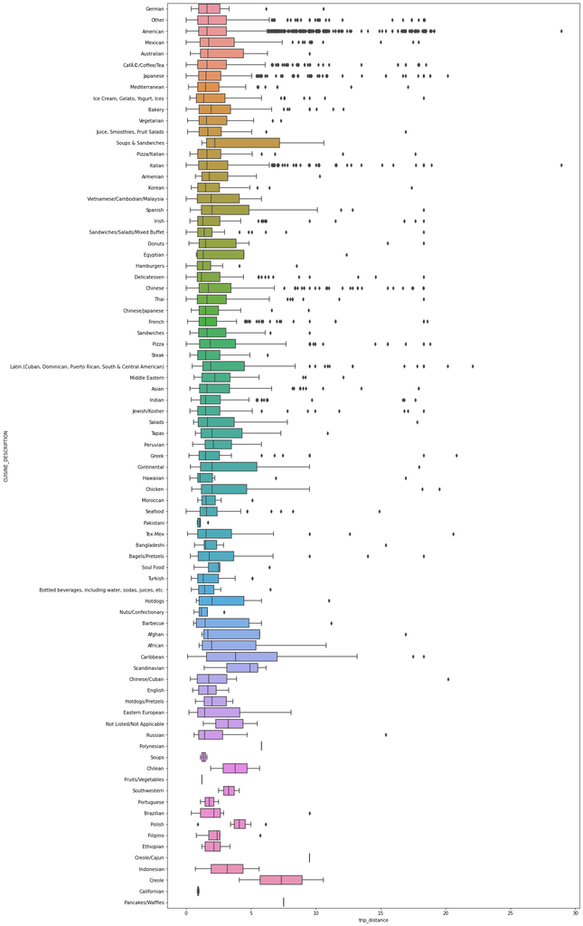

```python
import matplotlib.pyplot as plt
plt.figure(figsize= (16,36))
sns.boxplot(data=linked_data_1, y='CUISINE_DESCRIPTION', x='trip_distance')
```

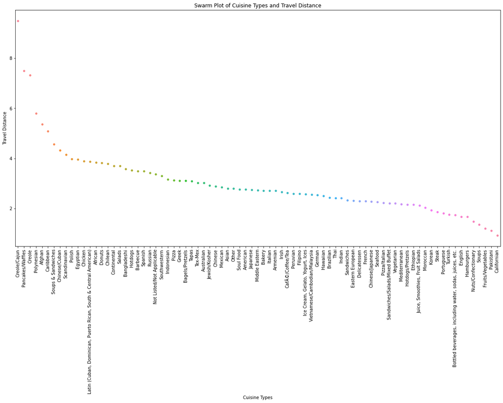

```python
'''
Grouping te linked data and finding the mean of the trip_distance to find the
average distance travelled by people to get the Cuisine_type specified by CUISINE_DESCRIPTION
'''
cuisine_trip = linked_data_1.groupby('CUISINE_DESCRIPTION').mean('trip_distance').reset_index()
import matplotlib.pyplot as plt
cuisine_trip = cuisine_trip.sort_values(by='trip_distance', ascending=False)
plt.figure(figsize= (20,10))
sns.swarmplot(data=cuisine_trip, y='trip_distance', x='CUISINE_DESCRIPTION')
plt.xlabel('Cuisine Types')
plt.xticks(rotation=90)
# set the y-axis label
plt.ylabel('Travel Distance')
# set the title
plt.title('Swarm Plot of Cuisine Types and Travel Distance')
# show the plot
plt.show()
```

**4a How far do people travel based on different types of cuisine (“CUISINE DESCRIPTION”)?**

- From the above Swarm plot it is evident that in order to get CUISINE named **"CREOLE/CAJUN"**, trip_distance is more. That means, people need to travel more distance to get it. On the other hand, **Californian foods** are more easily available.

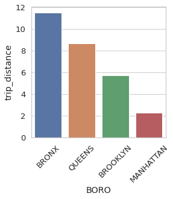

```python
'''
Grouping the linked data by BORO and finding the mean of the trip_distance to find the
average distance travelled by people to find the trip_distance travelled in each BORO.
'''
b4 = linked_data_1.groupby('BORO').mean('trip_distance').reset_index()
import matplotlib.pyplot as plt
plt.figure(figsize= (4,4))
b4 = b4.sort_values(by='trip_distance', ascending=False)
sns.barplot(data=b4, y='trip_distance', x='BORO')
plt.xticks(rotation=45)
plt.show()
```

**4a How does this differ based on the borough where the restaurant is located (“BORO”, one of 5 large NYC neighborhoods)?**

```python
linked_data_1["Meal"] = ["LUNCH" if x >= start_time1 and x <= end_time1 else "DINNER" for x in linked_data_1['TimeOfTheDay']]
```

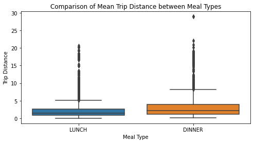

```python
meal_trip1 = linked_data_1[["Meal" , "trip_distance"]]
import matplotlib.pyplot as plt
plt.figure(figsize= (8,4))
# meal_trip1 = meal_trip1.sort_values(by='trip_distance', ascending=False)

# create the point plot
sns.boxplot(x='Meal', y='trip_distance', data=meal_trip1)

# set the x-axis label
plt.xlabel('Meal Type')

# set the y-axis label
plt.ylabel('Trip Distance')

# set the title
plt.title('Comparison of Mean Trip Distance between Meal Types')

# show the plot
plt.show()
```

**4a How does this differ by meal time?**

- Above boxplot depicts the relationship bettween average trip distance travelled for Dinner time and Lunch time. It can be seen that the median trip distance is almost same for lunch time and dinner time. But on clear examination people travel more for dinner time than in lunch time.

```python
linked_data_2 = pd.DataFrame().assign(TimeOfTheDay = restaurants_taxis_joined['tpep_dropoff_datetime'],\
                                    RESTAURANT = restaurants_taxis_joined["DBA"] ,\
                                    BORO = restaurants_taxis_joined["BORO"],\
                                    CUISINE_DESCRIPTION = restaurants_taxis_joined["CUISINE DESCRIPTION"],\
                                    tip_amount = restaurants_taxis_joined["tip_amount"],\
                                    passenger_count = restaurants_taxis_joined["passenger_count"])
linked_data_2 = linked_data_2.drop_duplicates(subset = ["RESTAURANT"])
len(linked_data_2)
```

```
7144
```

```python
linked_data_2.columns
```

```
Index(['TimeOfTheDay', 'RESTAURANT', 'BORO', 'CUISINE_DESCRIPTION',
       'tip_amount', 'passenger_count'],
      dtype='object')
```

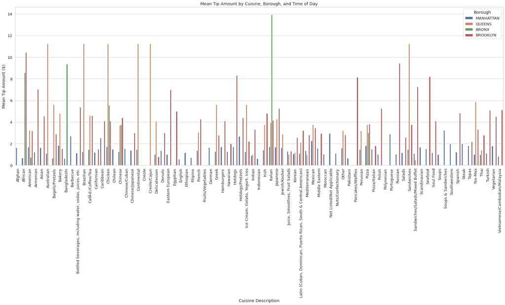

```python
'''
b. What is the average tipping rate for different types of cuisine?
How does this differ by borough, by meal time, and by number of passengers in the taxi?
'''
import matplotlib.pyplot as plt
linked_data_2["MEAL"] = linked_data_1["Meal"]
df_tip = linked_data_2[['tip_amount', 'CUISINE_DESCRIPTION', 'BORO', 'MEAL', 'passenger_count']]

# Group the data by cuisine, borough, time of day, and number of passengers, and calculate the mean tip for each group
grouped_tip = df_tip.groupby(['CUISINE_DESCRIPTION', 'BORO', 'MEAL', 'passenger_count']).mean().reset_index()

# Create a bar plot of mean tip by cuisine and borough
sns.set(style='whitegrid', font_scale=1.2)
plt.figure(figsize=(30,10))
sns.barplot(x='CUISINE_DESCRIPTION', y='tip_amount', hue='BORO', data=grouped_tip, ci=None)
plt.title('Mean Tip Amount by Cuisine, Borough, and Time of Day')
plt.xlabel('Cuisine Description')
plt.ylabel('Mean Tip Amount ($)')
plt.legend(title='Borough', loc='upper right')
plt.xticks(rotation=90)
plt.show()
```

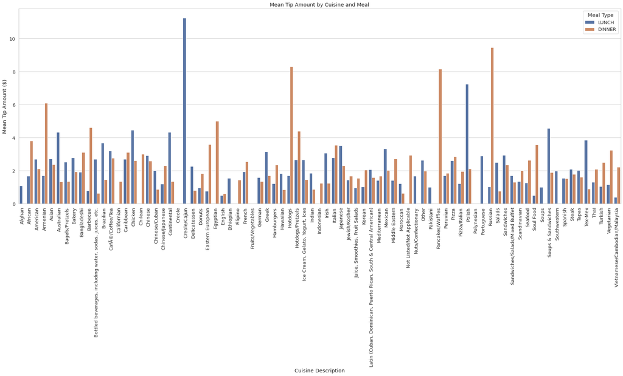

```python
# Create a bar plot of mean tip by cuisine and Meal
sns.set(style='whitegrid', font_scale=1.2)
plt.figure(figsize=(30 ,10))
sns.barplot(x='CUISINE_DESCRIPTION', y='tip_amount', hue='MEAL', data=grouped_tip, ci=None)
plt.title('Mean Tip Amount by Cuisine and Meal')
plt.xlabel('Cuisine Description')
plt.ylabel('Mean Tip Amount ($)')
plt.legend(title='Meal Type', loc='upper right')
plt.xticks(rotation=90)
plt.show()
```

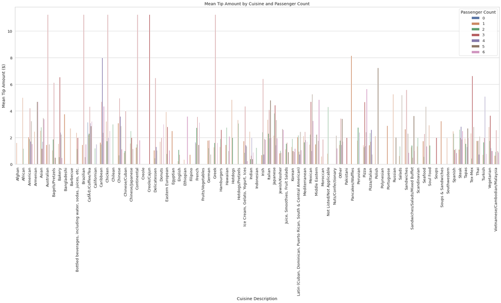

```python
# Create a bar plot of mean tip by cuisine and number of passengers
sns.set(style='whitegrid', font_scale=1.2)
plt.figure(figsize=(30 ,10))
sns.barplot(x='CUISINE_DESCRIPTION', y='tip_amount', hue='passenger_count', data=grouped_tip, ci=None)
plt.title('Mean Tip Amount by Cuisine and Passenger Count')
plt.xlabel('Cuisine Description')
plt.ylabel('Mean Tip Amount ($)')
plt.legend(title='Passenger Count', loc='upper right')
plt.xticks(rotation=90)
plt.show()
```

1. From the 1st bar plot we can say how the mean taxi tip of cuisine vary based on the borough of the restaurant.
2. From the 2nd bar plot we can say how the mean taxi tip of cusine vary based on the Meal type.
3. From the 3rd barplot we can say how the mean taxi tip of cuisine vary based on the Number of passengers boarding the taxi

## **5. Describe how you would set up a predictive model**

**Decision Trees are selected for this analysis** **Feature Set will include:**

- Trip distance (miles)
- Borough of restaurant
- Time of day
- Number of passengers in the taxi
- Day of the week

**MODEL BUILDING PROCESS**

1. **Data Preparation**: Combined the taxi and restaurant datasets spatially based on the assumption that all taxi trips during lunchtime and dinnertime were to restaurants. Preprocessed and cleaned the data, including encoding categorical variables (e.g. Borough, Day of Week, Time of Day).
2. **Feature Selection**: selected the relevant features that can help in predicting the cuisine type of a restaurant. In this case, we can use Trip Distance, Borough of Restaurant, Time of Day, Number of Passengers, and Day of the Week.
3. **Splitting the Data**: Data needed to be split into training and testing sets.
4. **Model Selection**: Choose a decision tree model for the classification problem. There are various algorithms available, such as ID3, C4.5, CART, etc. Choose an appropriate algorithm based on the size and complexity of the dataset.
5. **Model Training**: Train the decision tree model on the training set. Tune hyperparameters such as maximum depth, minimum samples per leaf, etc. to avoid overfitting.
6. **Model Evaluation**: Evaluate the model's performance on the testing set using metrics such as accuracy, precision, recall, and F1 score.
7. **Model Optimization**: If the model's performance is not satisfactory, perform feature engineering and hyperparameter tuning to optimize the model.
8. **Predictions**: Once the model is trained and optimized, use it to make predictions on new data.
9. **Monitoring and Maintenance**: Monitor the model's performance over time and maintain it by retraining on new data or updating hyperparameters as needed.

**Additional data sources that can be used to improve the predictive model are:**

- **Yelp API**: Additional information such as restaurant ratings, reviews, and menu items can be obtained from Yelp's API to enhance the feature set.
- **Weather Data**: Weather conditions may affect people's food choices and can be a useful feature to include in the model.
- **Demographic Data**: Demographic data such as age, income, and ethnicity of the restaurant's surrounding population may influence cuisine preferences and can be added to the feature set.
- **Traffic data**: Traffic data can be used to understand the impact of traffic on restaurant patronage. For example, if there is a lot of traffic in a certain area, people may be less likely to visit restaurants in that area.
- **Events data**: Events data can be used to understand the impact of events on restaurant patronage. For example, if there is a concert or sports game happening in a certain area, people may be more likely to visit restaurants in that area before or after the event.